# Análisis evolución Covid-19 Chile casos y decesos (21/04/2020)

Claudio Bustos

21/4/2020

- Reportes anteriores: https://github.com/clbustos/analisis_covid19_chile

## Análisis de series de casos

La serie de casos se hace hace partir de los 25 casos, excepto para Atacama y Aysén - donde no hay casos nuevos en los últimos días, para facilitar la comparación desde un punto de un punto de partida común.

En la serie total se puede apreciar un patrón de desaceleración lento, que parte hace 20 días. Este patrón parece ser producto de la estabilización de casos en diversas regiones, pero se ve contrarrestado por tasas estables o ascendentes en otras.

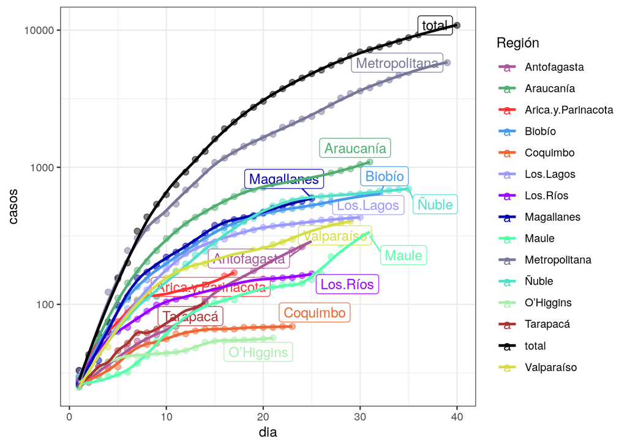

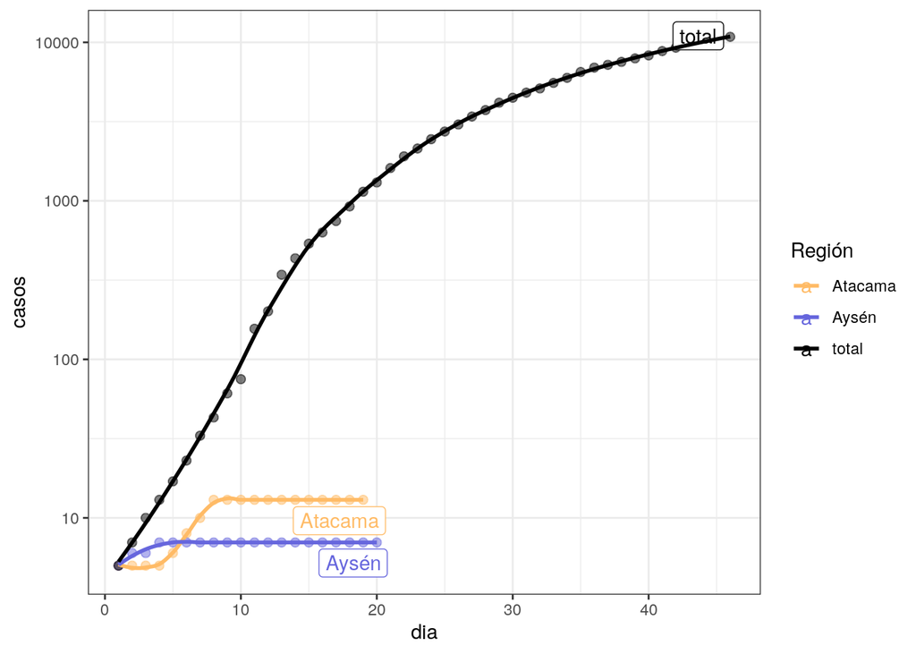

La serie por región se hace partir de los 5 primeros casos.

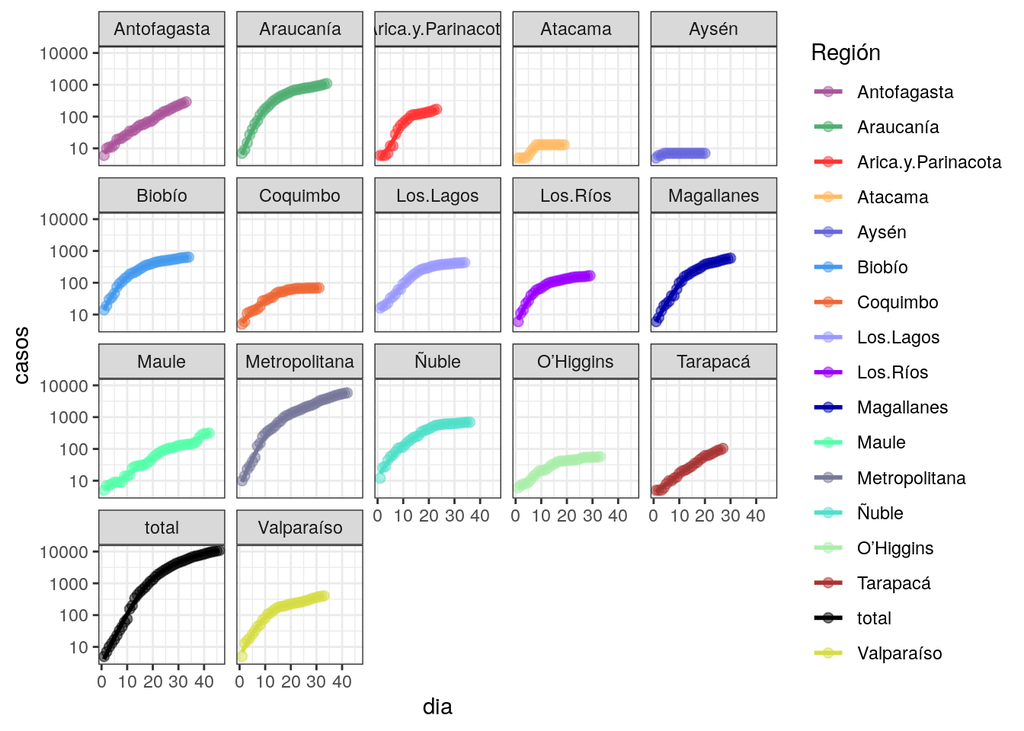

Con respecto a la cantidad de casos por día vs los del día previo, se puede ver un patrón ascendente en Arica y Parinacota, Araucanía, Los Ríos, así como un patrón estable en Tarapacá, Antofagasta y Valparaíso.

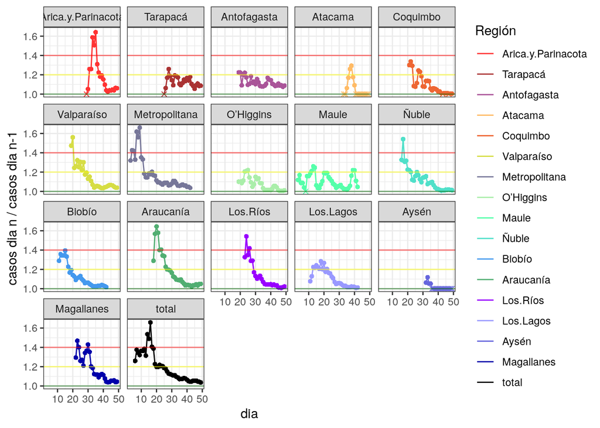

En la serie de tasas de casos nuevos, con una ventana de 7 días, se aprecia un patrón descendente en la serie total, y en las regiones Metropolitana, Biobío y los Ríos. Sin embargo, se aprecia un patrón ascendente en Valparaíso, Ñuble y la Araucanía.

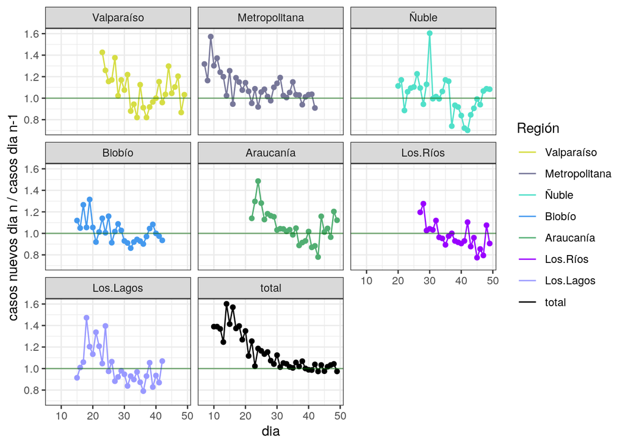

En el caso de Maule, se puede observar que en los últimos dos días se ha desacelerado la tendencia a la aceleración de los 5 días anteriores.

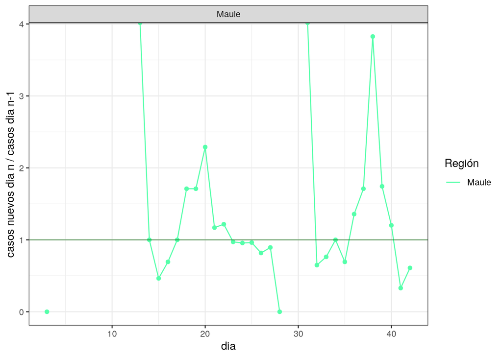

## Predicción

### Predicción para serie total

Recordemos que la regresión exponencial se eliminó, porque ya no calza con la serie total. El informe de la semana pasada mostró una subestimación constante de los modelos AR(1) + AR(4), y sobreestimación (lo que sabíamos), del modelo ARIMA. . Este último modelo se eliminará, ya que si bien los intervalos de confianza se cumplen, siempre sobreestima. A partir del análisis del resultado del algoritmo de la última semana, para la predicción total se recorta la serie a partir de lo 50 casos.

- tendencia sobre casos nuevos + AR(1) y sobre AR(4): Se modela la tendencia de los casos nuevos usando regresión exponencial, con regresión cuadradática, más la relación que existe entre mediciones contiguas. Se prueban dos modelos, uno que considera la relación solo entre cada tiempo y el anterior, AR(1), y un modelo más a largo plazo, que considera periodos de 4 días consecutivos, AR(4) . El error estándar aumenta a lo largo del tiempo, tanto por el error al calcular la tendencia, como por el componente autorregresivo. El valor medio obtenido es bastante sensible a los cambios en las mediciones finales.
- Modelo lineal cuadrático: Un modelo muy sencillo es modelar los casos totales con $ y= + _1 * dia + _2 * dia^2$, usando autocorrelación AR(2). Si bien en las pruebas muestra tener un intervalo de confianza malo y sobreestimar, tiende a tener menor error cuadrático.

Si observamos la predicción a 6 días plazo, podemos ver que el modelo cuadrático sobreestimó el valor observado en tanto que los modelos T+AR(1) u T+AR(4) subestimaron, como ha sido la tónica durante la semana. Nuevamente, el intervalo se ha mantenido para todas las predicciones.

|  | casos | li | ls |
| --- | --- | --- | --- |
| **Observado** | 10832 | NA | NA |
| **General: Cuadrático + AR(2)** | 11176 | 10729 | 11622 |
| **Casos nuevos : Tendencia + AR(1)** | 9670 | 9014 | 10908 |
| **Casos nuevos: Tendencia + AR(4)** | 9756 | 9079 | 11029 |

Podemos ver, al igual que en los días anteriores, que el modelo cuadrático es el más pesimista, pero los modelos T+AR(1) y T+AR(4) tienden a converger. En una semana deberíamos tener entre 12500 y 14500 casos.

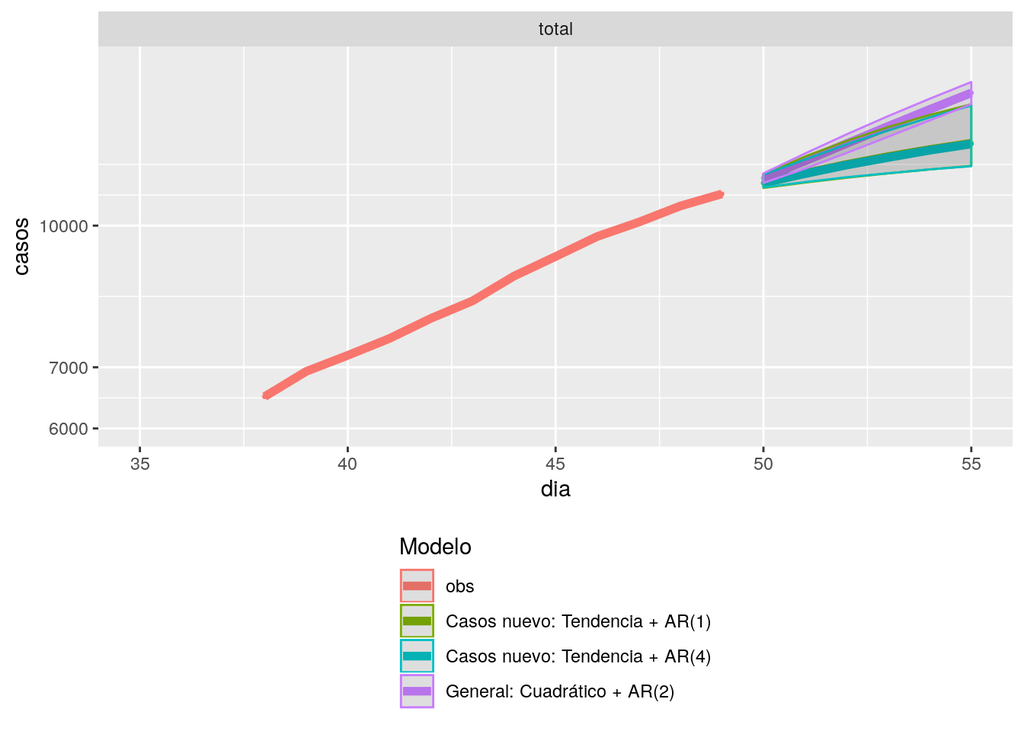

Casos nuevos: tendencia + AR(4) : total

|  | dia | casos | li | ls |
| --- | --- | --- | --- | --- |
| **39** | 50 | 11143 | 11012 | 11369 |
| **40** | 51 | 11398 | 11159 | 11811 |
| **41** | 52 | 11649 | 11296 | 12270 |
| **42** | 53 | 11871 | 11410 | 12705 |
| **43** | 54 | 12090 | 11521 | 13137 |
| **44** | 55 | 12283 | 11616 | 13530 |
| **45** | 56 | 12463 | 11703 | 13902 |

Casos nuevos: tendencia + AR(1) : total

|  | dia | casos | li | ls |
| --- | --- | --- | --- | --- |
| **39** | 50 | 11131 | 10995 | 11380 |
| **40** | 51 | 11409 | 11144 | 11900 |
| **41** | 52 | 11665 | 11281 | 12379 |
| **42** | 53 | 11900 | 11406 | 12818 |
| **43** | 54 | 12113 | 11520 | 13217 |
| **44** | 55 | 12305 | 11623 | 13577 |
| **45** | 56 | 12478 | 11715 | 13900 |

General: Modelo cuadrático : total

|  | dia | casos | li | ls |
| --- | --- | --- | --- | --- |
| **39** | 50 | 11272 | 11137 | 11407 |
| **40** | 51 | 11769 | 11545 | 11993 |
| **41** | 52 | 12297 | 12008 | 12585 |
| **42** | 53 | 12842 | 12509 | 13176 |
| **43** | 54 | 13401 | 13035 | 13767 |
| **44** | 55 | 13970 | 13582 | 14358 |
| **45** | 56 | 14548 | 14144 | 14952 |

### Predicciones para serie total usando predicción por regiones.

Otro modelo posible de análisis es usar la suma de las predicciones parciales por región. No he calculado los intervalos de confianza, porque para que sean adecuados debería considerar la covarianza entre las series de las distintas regiones.

El modelo AR(1) predice 13344, en tanto que el modelo cuadrático predice 14436.

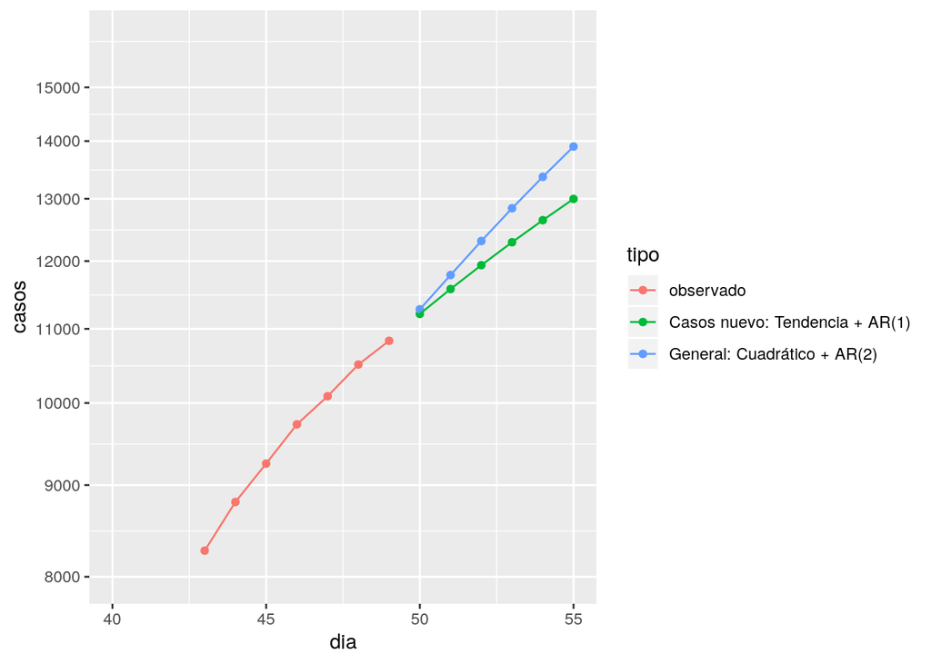

| dia | fecha | tipo | casos |
| --- | --- | --- | --- |
| 1 | 43893 | observado | 1 |
| 2 | 43894 | observado | 3 |
| 3 | 43895 | observado | 4 |
| 4 | 43896 | observado | 5 |
| 5 | 43897 | observado | 7 |
| 6 | 43898 | observado | 10 |
| 7 | 43899 | observado | 13 |
| 8 | 43900 | observado | 17 |
| 9 | 43901 | observado | 23 |
| 10 | 43902 | observado | 33 |
| 11 | 43903 | observado | 43 |
| 12 | 43904 | observado | 61 |
| 13 | 43905 | observado | 75 |
| 14 | 43906 | observado | 156 |
| 15 | 43907 | observado | 201 |
| 16 | 43908 | observado | 342 |
| 17 | 43909 | observado | 434 |
| 18 | 43910 | observado | 537 |
| 19 | 43911 | observado | 632 |
| 20 | 43912 | observado | 746 |
| 21 | 43913 | observado | 922 |
| 22 | 43914 | observado | 1142 |
| 23 | 43915 | observado | 1306 |
| 24 | 43916 | observado | 1610 |
| 25 | 43917 | observado | 1909 |
| 26 | 43918 | observado | 2139 |
| 27 | 43919 | observado | 2449 |
| 28 | 43920 | observado | 2738 |
| 29 | 43921 | observado | 3031 |
| 30 | 43922 | observado | 3404 |
| 31 | 43923 | observado | 3737 |
| 32 | 43924 | observado | 4161 |
| 33 | 43925 | observado | 4471 |
| 34 | 43926 | observado | 4815 |
| 35 | 43927 | observado | 5116 |
| 36 | 43928 | observado | 5546 |
| 37 | 43929 | observado | 5972 |
| 38 | 43930 | observado | 6501 |
| 39 | 43931 | observado | 6927 |
| 40 | 43932 | observado | 7213 |
| 41 | 43933 | observado | 7525 |
| 42 | 43934 | observado | 7917 |
| 43 | 43935 | observado | 8273 |
| 44 | 43936 | observado | 8807 |
| 45 | 43937 | observado | 9252 |
| 46 | 43938 | observado | 9730 |
| 47 | 43939 | observado | 10088 |
| 48 | 43940 | observado | 10507 |
| 49 | 43941 | observado | 10832 |
| 50 | 43942 | Casos nuevo: Tendencia + AR(1) | 11213 |
| 51 | 43943 | Casos nuevo: Tendencia + AR(1) | 11577 |
| 52 | 43944 | Casos nuevo: Tendencia + AR(1) | 11937 |
| 53 | 43945 | Casos nuevo: Tendencia + AR(1) | 12294 |
| 54 | 43946 | Casos nuevo: Tendencia + AR(1) | 12647 |
| 55 | 43947 | Casos nuevo: Tendencia + AR(1) | 12997 |
| 56 | 43948 | Casos nuevo: Tendencia + AR(1) | 13344 |
| 50 | 43942 | General: Cuadrático + AR(2) | 11280 |
| 51 | 43943 | General: Cuadrático + AR(2) | 11787 |
| 52 | 43944 | General: Cuadrático + AR(2) | 12313 |
| 53 | 43945 | General: Cuadrático + AR(2) | 12842 |
| 54 | 43946 | General: Cuadrático + AR(2) | 13371 |
| 55 | 43947 | General: Cuadrático + AR(2) | 13901 |
| 56 | 43948 | General: Cuadrático + AR(2) | 14436 |

### Predicción por regiones

Eliminaremos la predicción de Atacama y Aysén, que presentan tasas estabilizadas. Se pudo reincorporar Maule, que por su bruscos cambios no generaba una predicción estable para el modelo cuadrático. Recordemos que el algoritmo inicia desde 10 casos en cada Región.

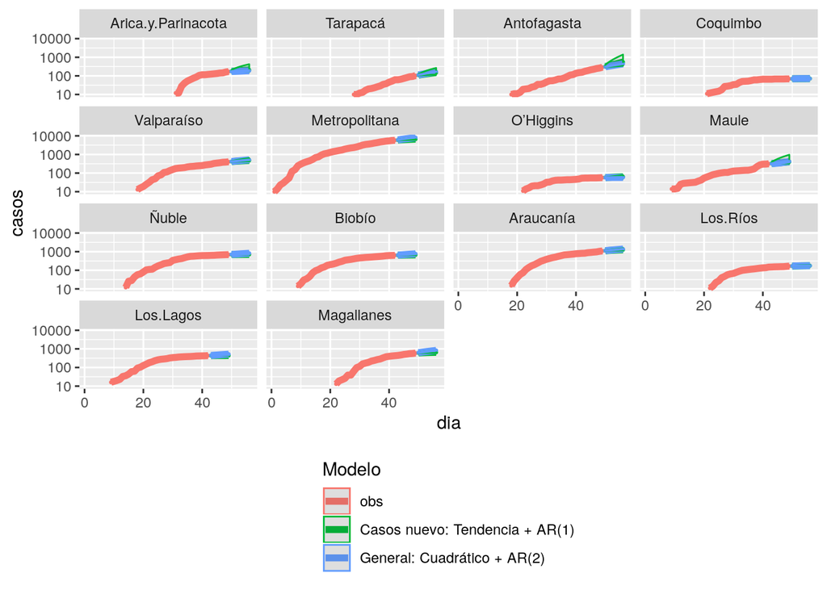

Las tablas por regiones se incluye en el Anexo I

## Ventiladores y Casos en UCI

Una primera serie es la de ventiladores disponibles. Se aprecia una tendencia al aumento de los ventiladores ocupados, de 986 a 1093 en 8 días.

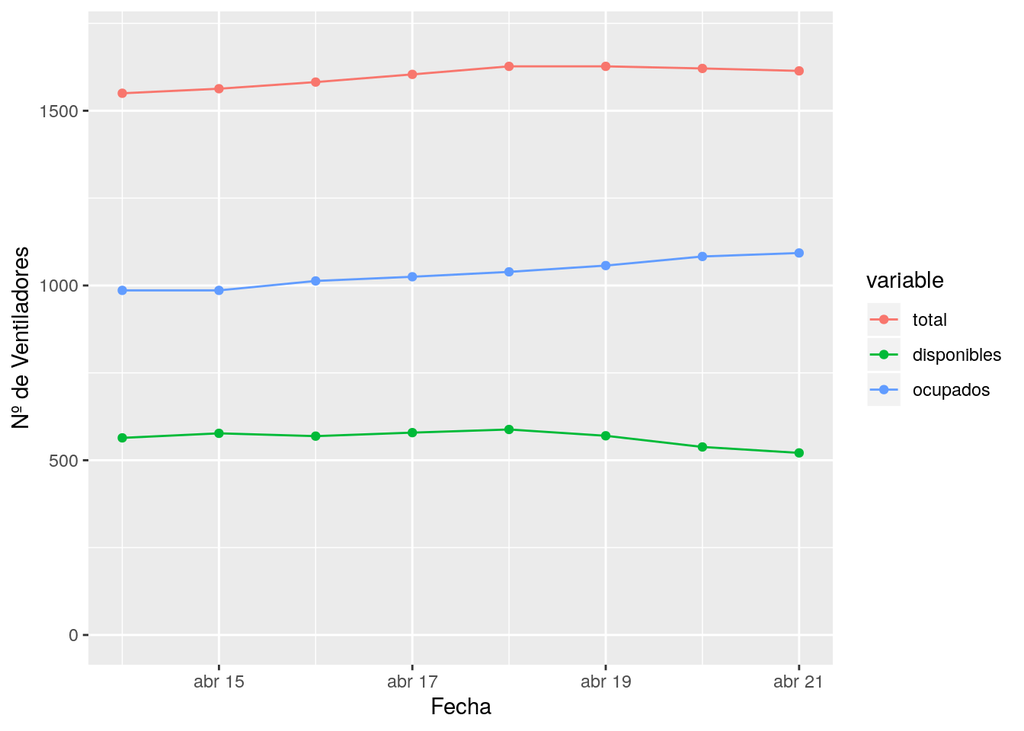

Si analizamos la serie total de pacientes en UCI para Covid-19, podemos ver que prácticamente se duplico desde inicios de mes hasta el 8 de Abril, para estabilizarse en cerca de 380 casos hasta el 20 de Abril. Hoy 21 tenemos 392 casos en UCI.

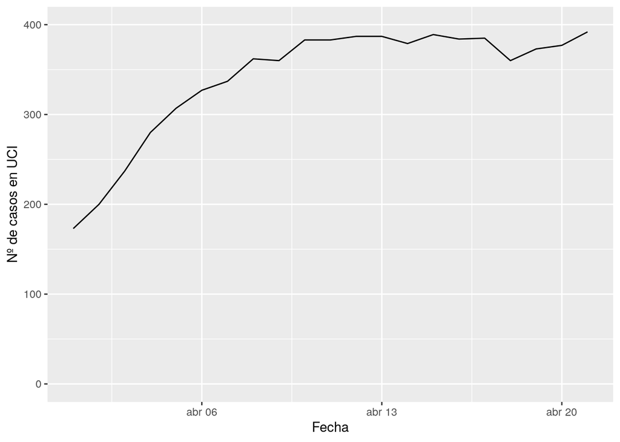

Al analizar la serie por regiones, podemos ver que en su mayoría los casos UCI se encuentran en la Región Metropolitana, siguiéndoles La Araucanía y Biobío, ambas con series descendentes desde aproximadamente 5 días. Es relevante notar el aumento fuerte en los casos UCI de los últimos 4 días.

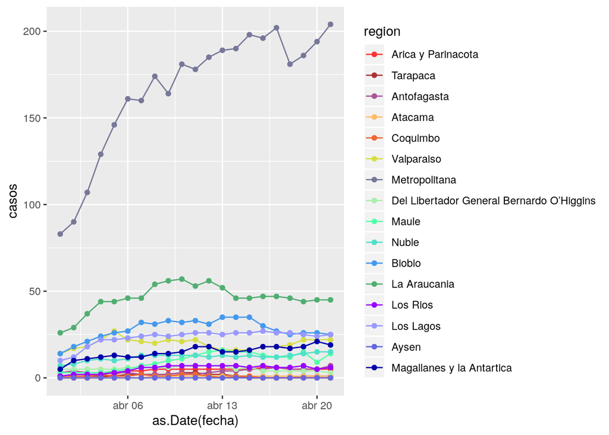

## Decesos

Si observamos la serie total de decesos, observamos una leve desaceleración de la tasa global. La tasa de la región metropolitana muestra una leve desaceleración en los últimos dos días.

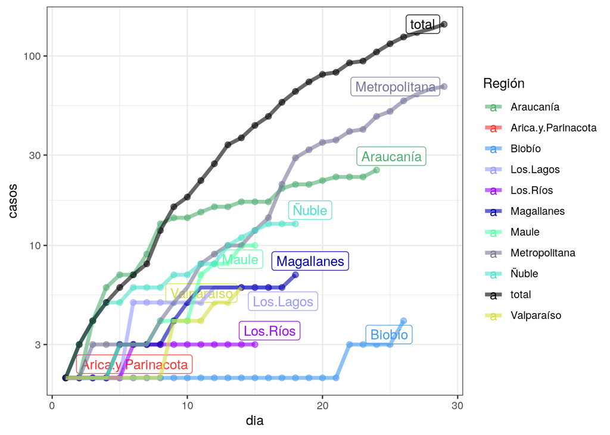

Maule y Ñuble han mantenido su tasa en el periodo considerado.

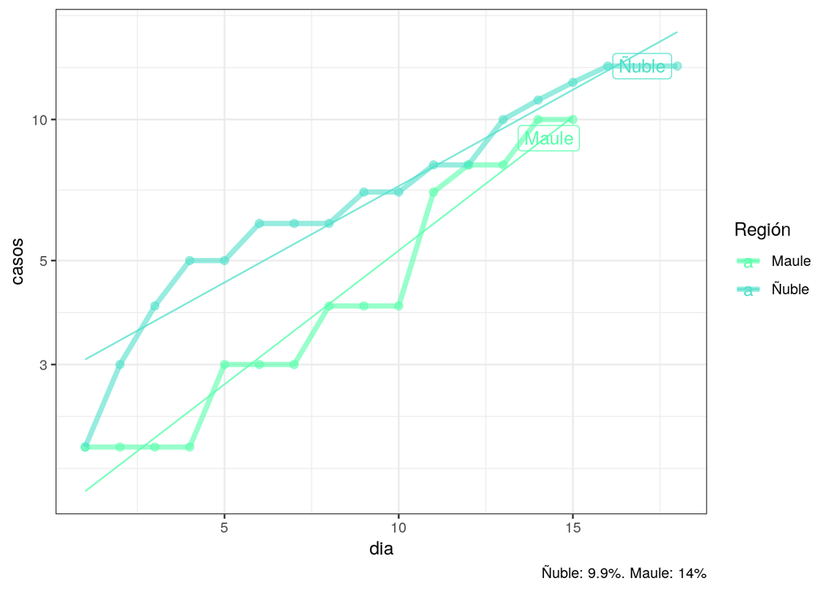

**Fuentes de información**: Principalmente, se utilizó el reporte diario del [MINSAL](https://www.minsal.cl/nuevo-coronavirus-2019-ncov/casos-confirmados-en-chile-covid-19/), usando [Wayback machine](https://archive.org/web/) para recopilar la información ya no disponible. También se ocupa la nueva serie disponible en el [Github del Ministerio de Ciencias](https://github.com/MinCiencia/Datos-COVID19).

## Anexo I: Predicciones por región

Casos nuevos: tendencia + AR(1) : Arica.y.Parinacota

|  | dia | casos | li | ls |
| --- | --- | --- | --- | --- |
| **20** | 50 | 176.2 | 170.9 | 210 |
| **21** | 51 | 182 | 171.8 | 248 |
| **22** | 52 | 187.6 | 172.7 | 284.8 |
| **23** | 53 | 193 | 173.5 | 320.5 |
| **24** | 54 | 198.3 | 174.3 | 355 |
| **25** | 55 | 203.4 | 175.1 | 388.3 |
| **26** | 56 | 208.3 | 175.9 | 420.4 |

Casos nuevos: tendencia + AR(1) : Tarapacá

|  | dia | casos | li | ls |
| --- | --- | --- | --- | --- |
| **23** | 50 | 109.8 | 105.7 | 124.2 |
| **24** | 51 | 116.7 | 107.6 | 148.6 |
| **25** | 52 | 123.3 | 109.5 | 172.3 |
| **26** | 53 | 130 | 111.3 | 196.2 |
| **27** | 54 | 136.6 | 113.2 | 219.8 |
| **28** | 55 | 143.2 | 115 | 243.2 |
| **29** | 56 | 149.6 | 116.8 | 266 |

Casos nuevos: tendencia + AR(1) : Antofagasta

|  | dia | casos | li | ls |
| --- | --- | --- | --- | --- |
| **33** | 50 | 317.1 | 297.4 | 398.1 |
| **34** | 51 | 347.2 | 304.4 | 526 |
| **35** | 52 | 380.1 | 312.1 | 666.4 |
| **36** | 53 | 416.5 | 320.7 | 821.8 |
| **37** | 54 | 456.7 | 330.1 | 993.4 |
| **38** | 55 | 501.2 | 340.5 | 1183 |
| **39** | 56 | 550.3 | 352.1 | 1393 |

Casos nuevos: tendencia + AR(1) : Coquimbo

|  | dia | casos | li | ls |
| --- | --- | --- | --- | --- |
| **30** | 50 | 69.54 | 69.14 | 71.11 |
| **31** | 51 | 70.01 | 69.26 | 72.96 |
| **32** | 52 | 70.4 | 69.36 | 74.47 |
| **33** | 53 | 70.71 | 69.44 | 75.69 |
| **34** | 54 | 70.96 | 69.5 | 76.68 |
| **35** | 55 | 71.16 | 69.55 | 77.46 |
| **36** | 56 | 71.32 | 69.59 | 78.07 |

Casos nuevos: tendencia + AR(1) : Valparaíso

|  | dia | casos | li | ls |
| --- | --- | --- | --- | --- |
| **33** | 50 | 414.9 | 406.8 | 440.3 |
| **34** | 51 | 426.1 | 410.3 | 475.8 |
| **35** | 52 | 436.9 | 413.8 | 510 |
| **36** | 53 | 447.3 | 417.1 | 542.7 |
| **37** | 54 | 457.2 | 420.2 | 573.9 |
| **38** | 55 | 466.6 | 423.2 | 603.6 |
| **39** | 56 | 475.5 | 426 | 631.7 |

Casos nuevos: tendencia + AR(1) : Metropolitana

|  | dia | casos | li | ls |
| --- | --- | --- | --- | --- |
| **43** | 43 | 5945 | 5854 | 6161 |
| **44** | 44 | 6096 | 5917 | 6527 |
| **45** | 45 | 6236 | 5974 | 6866 |
| **46** | 46 | 6364 | 6027 | 7177 |
| **47** | 47 | 6480 | 6075 | 7459 |
| **48** | 48 | 6585 | 6118 | 7713 |
| **49** | 49 | 6678 | 6156 | 7940 |

Casos nuevos: tendencia + AR(1) : O’Higgins

|  | dia | casos | li | ls |
| --- | --- | --- | --- | --- |
| **29** | 50 | 57.96 | 57.3 | 60.08 |
| **30** | 51 | 58.9 | 57.59 | 63.07 |
| **31** | 52 | 59.8 | 57.87 | 65.98 |
| **32** | 53 | 60.68 | 58.15 | 68.81 |
| **33** | 54 | 61.53 | 58.41 | 71.55 |
| **34** | 55 | 62.36 | 58.67 | 74.21 |
| **35** | 56 | 63.17 | 58.92 | 76.8 |

Casos nuevos: tendencia + AR(1) : Maule

|  | dia | casos | li | ls |
| --- | --- | --- | --- | --- |
| **35** | 43 | 327.6 | 317.7 | 394.5 |
| **36** | 44 | 339.2 | 319.2 | 483.6 |
| **37** | 45 | 351 | 320.7 | 575.6 |
| **38** | 46 | 363 | 322.3 | 669.5 |
| **39** | 47 | 375.3 | 323.9 | 765.3 |
| **40** | 48 | 387.8 | 325.4 | 862.8 |
| **41** | 49 | 400.5 | 327.1 | 961.9 |

Casos nuevos: tendencia + AR(1) : Ñuble

|  | dia | casos | li | ls |
| --- | --- | --- | --- | --- |
| **37** | 50 | 698.5 | 695.1 | 713.3 |
| **38** | 51 | 702.2 | 695.9 | 729.1 |
| **39** | 52 | 705.3 | 696.6 | 742.1 |
| **40** | 53 | 707.8 | 697.2 | 752.7 |
| **41** | 54 | 709.8 | 697.7 | 761.4 |
| **42** | 55 | 711.4 | 698.1 | 768.2 |
| **43** | 56 | 712.7 | 698.4 | 773.7 |

Casos nuevos: tendencia + AR(1) : Biobío

|  | dia | casos | li | ls |
| --- | --- | --- | --- | --- |
| **35** | 43 | 644 | 639.6 | 653.8 |
| **36** | 44 | 650.9 | 642.7 | 669.2 |
| **37** | 45 | 656.9 | 645.4 | 682.5 |
| **38** | 46 | 662 | 647.6 | 693.9 |
| **39** | 47 | 666.3 | 649.6 | 703.5 |
| **40** | 48 | 669.9 | 651.2 | 711.7 |
| **41** | 49 | 673 | 652.6 | 718.5 |

Casos nuevos: tendencia + AR(1) : Araucanía

|  | dia | casos | li | ls |
| --- | --- | --- | --- | --- |
| **33** | 50 | 1124 | 1105 | 1171 |
| **34** | 51 | 1151 | 1115 | 1242 |
| **35** | 52 | 1176 | 1125 | 1307 |
| **36** | 53 | 1200 | 1134 | 1367 |
| **37** | 54 | 1222 | 1143 | 1424 |
| **38** | 55 | 1242 | 1150 | 1477 |
| **39** | 56 | 1261 | 1158 | 1526 |

Casos nuevos: tendencia + AR(1) : Los.Ríos

|  | dia | casos | li | ls |
| --- | --- | --- | --- | --- |
| **29** | 50 | 168.6 | 167.5 | 172 |
| **30** | 51 | 170.1 | 168 | 176.6 |
| **31** | 52 | 171.4 | 168.4 | 180.6 |
| **32** | 53 | 172.6 | 168.8 | 184.1 |
| **33** | 54 | 173.5 | 169.1 | 187.1 |
| **34** | 55 | 174.4 | 169.4 | 189.7 |
| **35** | 56 | 175.1 | 169.6 | 191.9 |

Casos nuevos: tendencia + AR(1) : Los.Lagos

|  | dia | casos | li | ls |
| --- | --- | --- | --- | --- |
| **35** | 43 | 433.9 | 432.6 | 437.7 |
| **36** | 44 | 435.6 | 433.2 | 442.8 |
| **37** | 45 | 436.8 | 433.6 | 446.6 |
| **38** | 46 | 437.7 | 433.9 | 449.4 |
| **39** | 47 | 438.4 | 434.1 | 451.5 |
| **40** | 48 | 438.9 | 434.2 | 453 |
| **41** | 49 | 439.2 | 434.4 | 454.1 |

Casos nuevos: tendencia + AR(1) : Magallanes

|  | dia | casos | li | ls |
| --- | --- | --- | --- | --- |
| **29** | 50 | 605.1 | 596.2 | 638.6 |
| **30** | 51 | 617 | 599.3 | 684.6 |
| **31** | 52 | 626.8 | 601.8 | 722.4 |
| **32** | 53 | 635 | 603.9 | 754 |
| **33** | 54 | 641.7 | 605.7 | 780 |
| **34** | 55 | 647.1 | 607.1 | 801 |
| **35** | 56 | 651.4 | 608.2 | 817.7 |

General: cuadrático + AR(2) : Arica.y.Parinacota

|  | dia | casos | li | ls |
| --- | --- | --- | --- | --- |
| **20** | 50 | 172.8 | 162.5 | 183.2 |
| **21** | 51 | 174.2 | 160.7 | 187.6 |
| **22** | 52 | 176.3 | 162.4 | 190.1 |
| **23** | 53 | 179.4 | 165.5 | 193.2 |
| **24** | 54 | 182.8 | 168.8 | 196.7 |
| **25** | 55 | 185.9 | 171.9 | 199.9 |
| **26** | 56 | 188.4 | 174.4 | 202.4 |

General: cuadrático + AR(2) : Tarapacá

|  | dia | casos | li | ls |
| --- | --- | --- | --- | --- |
| **23** | 50 | 112.4 | 108.3 | 116.5 |
| **24** | 51 | 120.7 | 116.4 | 125 |
| **25** | 52 | 129.5 | 125.2 | 133.8 |
| **26** | 53 | 138.8 | 134.5 | 143 |
| **27** | 54 | 148.3 | 144.1 | 152.6 |
| **28** | 55 | 158.3 | 154 | 162.6 |
| **29** | 56 | 168.6 | 164.3 | 172.8 |

General: cuadrático + AR(2) : Antofagasta

|  | dia | casos | li | ls |
| --- | --- | --- | --- | --- |
| **33** | 50 | 308.3 | 299.5 | 317 |
| **34** | 51 | 328.7 | 318.4 | 338.9 |
| **35** | 52 | 349.4 | 338.2 | 360.7 |
| **36** | 53 | 371.1 | 359.2 | 383 |
| **37** | 54 | 393.5 | 381.3 | 405.8 |
| **38** | 55 | 416.7 | 404.3 | 429.2 |
| **39** | 56 | 440.7 | 428.1 | 453.3 |

General: cuadrático + AR(2) : Coquimbo

|  | dia | casos | li | ls |
| --- | --- | --- | --- | --- |
| **30** | 50 | 69.84 | 65.14 | 74.54 |
| **31** | 51 | 70.65 | 64.17 | 77.13 |
| **32** | 52 | 71.24 | 63.97 | 78.5 |
| **33** | 53 | 71.58 | 63.98 | 79.19 |
| **34** | 54 | 71.72 | 63.98 | 79.46 |
| **35** | 55 | 71.66 | 63.86 | 79.46 |
| **36** | 56 | 71.45 | 63.62 | 79.27 |

General: cuadrático + AR(2) : Valparaíso

|  | dia | casos | li | ls |
| --- | --- | --- | --- | --- |
| **33** | 50 | 418.6 | 404.7 | 432.5 |
| **34** | 51 | 434.4 | 416 | 452.8 |
| **35** | 52 | 450.4 | 429.7 | 471.1 |
| **36** | 53 | 466.6 | 444.7 | 488.5 |
| **37** | 54 | 482.9 | 460.3 | 505.5 |
| **38** | 55 | 499.4 | 476.4 | 522.4 |
| **39** | 56 | 516.1 | 492.9 | 539.4 |

General: cuadrático + AR(2) : Metropolitana

|  | dia | casos | li | ls |
| --- | --- | --- | --- | --- |
| **43** | 43 | 6068 | 5972 | 6165 |
| **44** | 44 | 6403 | 6266 | 6539 |
| **45** | 45 | 6749 | 6598 | 6900 |
| **46** | 46 | 7091 | 6936 | 7245 |
| **47** | 47 | 7427 | 7272 | 7582 |
| **48** | 48 | 7761 | 7607 | 7916 |
| **49** | 49 | 8098 | 7944 | 8253 |

General: cuadrático + AR(2) : O’Higgins

|  | dia | casos | li | ls |
| --- | --- | --- | --- | --- |
| **29** | 50 | 57.6 | 54.83 | 60.37 |
| **30** | 51 | 57.95 | 54.32 | 61.58 |
| **31** | 52 | 58.18 | 54.38 | 61.98 |
| **32** | 53 | 58.34 | 54.53 | 62.14 |
| **33** | 54 | 58.43 | 54.62 | 62.24 |
| **34** | 55 | 58.45 | 54.64 | 62.26 |
| **35** | 56 | 58.39 | 54.57 | 62.2 |

General: cuadrático + AR(2) : Maule

|  | dia | casos | li | ls |
| --- | --- | --- | --- | --- |
| **35** | 43 | 323 | 306.8 | 339.3 |
| **36** | 44 | 329.5 | 301.3 | 357.8 |
| **37** | 45 | 338.9 | 303.3 | 374.5 |
| **38** | 46 | 352.8 | 314.2 | 391.3 |
| **39** | 47 | 371.4 | 332.4 | 410.4 |
| **40** | 48 | 393.6 | 354.6 | 432.7 |
| **41** | 49 | 417.9 | 378.3 | 457.5 |

General: cuadrático + AR(2) : Ñuble

|  | dia | casos | li | ls |
| --- | --- | --- | --- | --- |
| **37** | 50 | 709 | 678.5 | 739.5 |
| **38** | 51 | 727 | 677.1 | 776.9 |
| **39** | 52 | 746 | 682.2 | 809.7 |
| **40** | 53 | 765.1 | 691.6 | 838.6 |
| **41** | 54 | 783.9 | 703.5 | 864.4 |
| **42** | 55 | 802.4 | 717.1 | 887.7 |
| **43** | 56 | 820.5 | 731.7 | 909.4 |

General: cuadrático + AR(2) : Biobío

|  | dia | casos | li | ls |
| --- | --- | --- | --- | --- |
| **35** | 43 | 652.3 | 635.1 | 669.5 |
| **36** | 44 | 671.1 | 643.4 | 698.8 |
| **37** | 45 | 690.7 | 655.8 | 725.6 |
| **38** | 46 | 710.4 | 670.8 | 750 |
| **39** | 47 | 730 | 687.3 | 772.6 |
| **40** | 48 | 749.2 | 704.5 | 793.9 |
| **41** | 49 | 768.2 | 722.2 | 814.2 |

General: cuadrático + AR(2) : Araucanía

|  | dia | casos | li | ls |
| --- | --- | --- | --- | --- |
| **33** | 50 | 1135 | 1106 | 1164 |
| **34** | 51 | 1177 | 1132 | 1221 |
| **35** | 52 | 1218 | 1164 | 1272 |
| **36** | 53 | 1259 | 1200 | 1319 |
| **37** | 54 | 1301 | 1238 | 1364 |
| **38** | 55 | 1343 | 1278 | 1408 |
| **39** | 56 | 1385 | 1319 | 1451 |

General: cuadrático + AR(2) : Los.Ríos

|  | dia | casos | li | ls |
| --- | --- | --- | --- | --- |
| **29** | 50 | 169.4 | 164.2 | 174.6 |
| **30** | 51 | 170.9 | 164.8 | 177 |
| **31** | 52 | 172.3 | 166.2 | 178.4 |
| **32** | 53 | 173.6 | 167.5 | 179.7 |
| **33** | 54 | 174.7 | 168.6 | 180.8 |
| **34** | 55 | 175.6 | 169.5 | 181.8 |
| **35** | 56 | 176.2 | 170.1 | 182.4 |

General: cuadrático + AR(2) : Los.Lagos

|  | dia | casos | li | ls |
| --- | --- | --- | --- | --- |
| **35** | 43 | 442.6 | 426.9 | 458.3 |
| **36** | 44 | 454.5 | 426.9 | 482 |
| **37** | 45 | 467 | 430 | 503.9 |
| **38** | 46 | 479.7 | 435.6 | 523.7 |
| **39** | 47 | 492.3 | 443.1 | 541.6 |
| **40** | 48 | 504.8 | 451.8 | 557.8 |
| **41** | 49 | 517 | 461.4 | 572.7 |

General: cuadrático + AR(2) : Magallanes

|  | dia | casos | li | ls |
| --- | --- | --- | --- | --- |
| **29** | 50 | 625.3 | 603.1 | 647.5 |
| **30** | 51 | 658.8 | 626.8 | 690.8 |
| **31** | 52 | 692.3 | 655.6 | 729 |
| **32** | 53 | 725.5 | 686.7 | 764.4 |
| **33** | 54 | 758.6 | 718.9 | 798.4 |
| **34** | 55 | 791.8 | 751.7 | 831.9 |
| **35** | 56 | 825.2 | 784.9 | 865.4 |